# Worldbank population wrangling

Allison Horst

9/23/2020

Get data:

```r
wb_pop <- read_csv(here("data","world_bank_pop.csv"))
# Explore the data and ask: how are the data NOT tidy?
```

We have one clear issue that make these data *not* tidy. The year should be a single variable (column), but it is split up by individual years. We *may* consider total and urban populations separate variables (this one is a bit of a gray area).

We will use pivot_longer() and pivot_wider() from the `tidyr` package to help us reshape this data into tidy format.

First, by gathering the year data with pivot_longer():

```r
wb_pop_long <- wb_pop %>%
  pivot_longer(cols = '2000':'2017',
               names_to = "year",
               values_to = "population")
```

Then, we’ll split the two population measures into separate columns using `pivot_wider()`, then clean up the names, then make sure year is numeric:

```r
wb_pop_tidy <- wb_pop_long %>%
  pivot_wider(names_from = indicator,
              values_from = population) %>%
  clean_names() %>%
  mutate(year = as.numeric(year))
```

## Git Check!

Stage, commit, PULL, then push to GitHub. Ensure that the updates are stored by refreshing your repo on GitHub! Then come back to RStudio.

### Wrangling & graphs

Now we have our data in tidy format, and have made sure our updates are safely stored, let’s do some wrangling & make some plots!

```r
# Filter to China (CHN), India (IND), USA (USA), Indonesia (IDN), Brazil (BRA)

top5_pop <- wb_pop_tidy %>%
  filter(country %in% c("CHN", "IND", "USA", "IDN", "BRA"))
```

Then make a graph for each country’s total population over time:

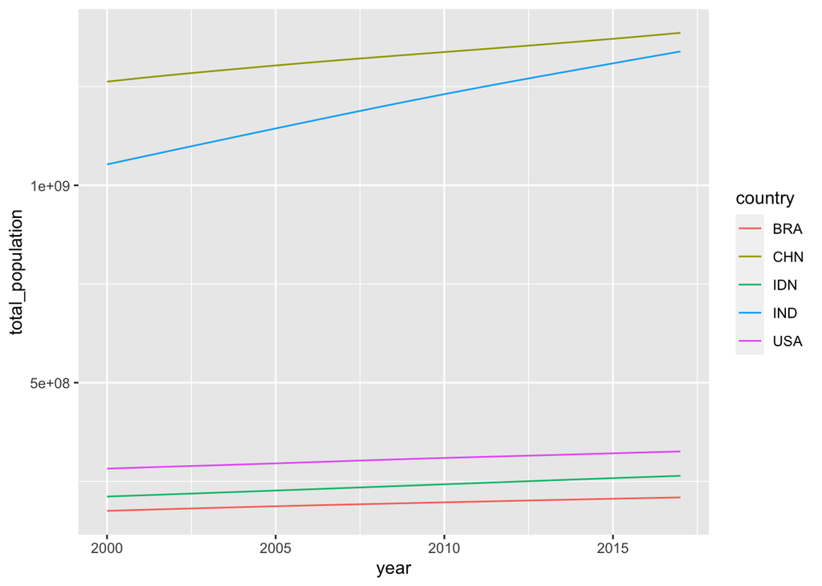

```r
ggplot(data = top5_pop, aes(x = year, y = total_population)) +
  geom_line(aes(color = country))
```

### Git Check

Knit (& save), stage, commit, PULL, then push changes to GitHub.

Go to GitHub & refresh repo to ensure it’s updated.

Come back to RStudio, CLOSE project & restart R. Reopen the project, PULL to make sure it’s updated, then you can keep working.